# MyDataPreparation and Modelling for Yeild Prediction

# Model Building and Tuning:

```r
lmFit <- train(yield ~ ., data = dev, method = "rf")
summary(lmFit)
```

```
##                 Length Class      Mode
## call              4    -none-     call
## type              1    -none-     character
## predicted        35    -none-     numeric
## mse             500    -none-     numeric
## rsq             500    -none-     numeric
## oob.times        35    -none-     numeric
## importance       84    -none-     numeric
## importanceSD      0    -none-     NULL
## localImportance   0    -none-     NULL
## proximity         0    -none-     NULL
## ntree             1    -none-     numeric
## mtry              1    -none-     numeric
## forest           11    -none-     list
## coefs             0    -none-     NULL
## y                35    -none-     numeric
## test              0    -none-     NULL
## inbag             0    -none-     NULL
## xNames           84    -none-     character
## problemType       1    -none-     character
## tuneValue         1    data.frame list
## obsLevels         1    -none-     logical
## param             0    -none-     list
```

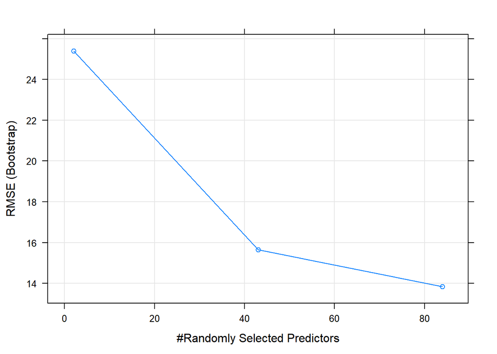

```r
plot(lmFit)
```

# Another useful function would be “trainControl” which allows for estimation of parameter coefficients through resampling methods

# like cross validation, boosting etc.

```r
ctrl<-trainControl(method = "cv" ,number = 10)
lmCVFit<-train(yield ~ ., data = featuresData, method = "rf", trControl = ctrl, metric= "Rsquared")
summary(lmCVFit)
```

```
##                 Length Class      Mode
## call              4    -none-     call
## type              1    -none-     character
## predicted        43    -none-     numeric
## mse             500    -none-     numeric
## rsq             500    -none-     numeric
## oob.times        43    -none-     numeric
## importance       84    -none-     numeric
## importanceSD      0    -none-     NULL
## localImportance   0    -none-     NULL
## proximity         0    -none-     NULL
## ntree             1    -none-     numeric
## mtry              1    -none-     numeric
## forest           11    -none-     list
## coefs             0    -none-     NULL
## y                43    -none-     numeric
## test              0    -none-     NULL
## inbag             0    -none-     NULL
## xNames           84    -none-     character
## problemType       1    -none-     character
## tuneValue         1    data.frame list
## obsLevels         1    -none-     logical
## param             0    -none-     list
```

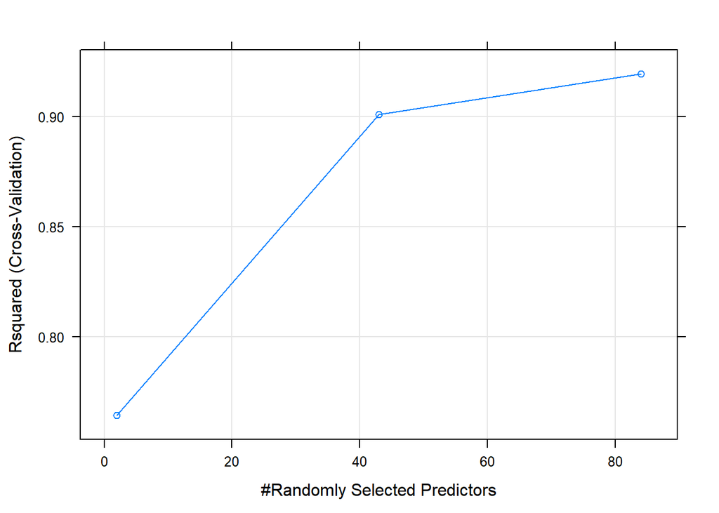

```r
plot(lmCVFit)
```

# Model Diagnostics and Scoring:

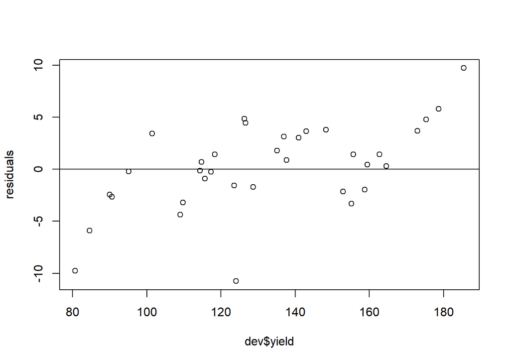

```r
residuals<-resid(lmFit)
predictedValues<-predict(lmFit)
plot(dev$yield,residuals)
abline(0,0)
```

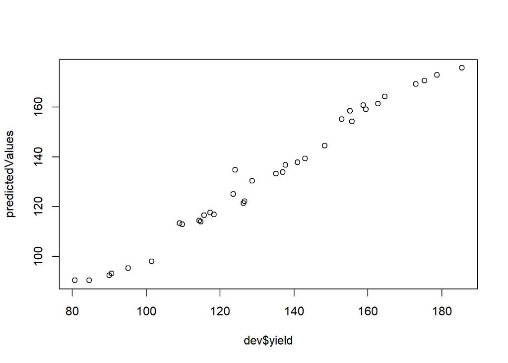

```r
plot(dev$yield,predictedValues)
```

# function “defaultSummary” can be used which in this example returns the values of R-squared and RMSE metrics

```r
predictedVal<-predict(lmFit,val)
modelvalues<-data.frame(obs = val$yield, pred=predictedVal)
defaultSummary(modelvalues)
```

```
##      RMSE  Rsquared
## 7.4471552 0.9776142
```

```r
predictedVal_cv<-predict(lmCVFit,val)
modelvalues_cv<-data.frame(obs = val$yield, pred=predictedVal_cv)
defaultSummary(modelvalues_cv)
```

```
##      RMSE  Rsquared
## 2.9007393 0.9959191
```

# Lets predict the yeild for the year 2018

```r
testyear = tail(featuresData, 10)
myNumCols <- which(unlist(lapply(testyear, is.numeric)))
testyear[(nrow(testyear) + 1), myNumCols] <- colMeans(testyear[, myNumCols], na.rm=TRUE)
testyear$year[testyear$year == 2012.5] <- 2018
test = tail(testyear, 1)
```

# SO im assuming and taking the average values for the last 10 years to determine the average temp from Jan to Dec, Precipation from Jan to dec

# is approximately same as the average of last 10 years

```r
predictedVal_2018<-predict(lmCVFit,test)
modelvalues_2018<-data.frame(value=c("yeild for the year 2018"), year = test$year, pred=predictedVal_2018)
modelvalues_2018
```

```
##                      value year     pred
## 11 yeild for the year 2018 2018 169.6597
```

# Model 2

## Initialization

```r
train.data <- featuresData[,c(2, 1, 3:85)]
test.data <- test[,c(2, 1, 3:85)]
```

## Setting Up and Connecting to a H2O Cluster

Letâs first load some packages

```r
# H2O is an R package
library(h2o)
```

```r
# Create an H2O cloud
h20package<-h2o.init(
  nthreads=-1,            #use available threads
  max_mem_size = "16G")   # specify the memory size for the H2O cloud
```

[output not shown]

```r
h2o.removeAll() ## clean slate - just in case the cluster was already running
```

```
## [1] 0
```

## View information about the model.

```r
train_h2o <- as.h2o(train.data)
test_h2o  <- as.h2o(test.data)
#Set timer:
timer <- proc.time()

system.time(
dlearning.model <- h2o.randomForest(
                                  x=2:(ncol(train_h2o)-1),
                                  y=1,
                                  training_frame = train_h2o,
                                  ntrees = 600,
                                  max_depth = 25,
                                  sample_rate = 0.95
                                  )
)
```

```
##    user  system elapsed
##    0.20    0.03    6.59
```

```r
h2o.performance(dlearning.model)
```

```
## H2ORegressionMetrics: drf
## ** Reported on training data. **
## ** Metrics reported on Out-Of-Bag training samples **
##
## MSE:  142.3438
## RMSE:  11.93079
## MAE:  8.67996
## RMSLE:  0.09747955
## Mean Residual Deviance :  142.3438
```

## Using the model for prediction

## Generate the submission.

```r
predict.dl3 <- as.data.frame(h2o.predict(dlearning.model, test_h2o))
modelvalues_2018_rf <-data.frame(value=c("yeild for the year 2018"), year = test.data$year, pred=predict.dl3)
modelvalues_2018_rf
```

```
##                     value year  predict
## 1 yeild for the year 2018 2018 171.9885
```

### All done, shutdown H2O

```r
h2o.shutdown(prompt=FALSE)
```

```
## [1] TRUE
```

## Resources

[Deep Learning with H2O](https://www.r-bloggers.com/things-to-try-after-user-part-1-deep-learning-with-h2o/) [Package âh2oâ](https://cran.r-project.org/web/packages/h2o/h2o.pdf) [h2o-tutorials](https://github.com/h2oai/h2o-tutorials/tree/master/tutorials/deeplearning)

# References

## Data

### All the data used below is been downaloaded from open source like ;

### Monthly temperature, precipitation ; ftp://ftp.ncdc.noaa.gov/pub/data/cirs/climdiv/ ; https://data.ers.usda.gov/FEED-GRAINS-custom-query.aspx

### Planting progress ; https://quickstats.nass.usda.gov/results/0D72DC4F-11B7-35DE-A5B1-D6AA348291F4

### continuous corn futures index ; https://www.quandl.com/data/CHRIS/CME_C1-Corn-Futures-Continuous-Contract-1-C1-Front-Month

### BBeginning-of-year corn grain stockpiles ; https://data.ers.usda.gov/FEED-GRAINS-custom-query.aspx#ResultsPanel

### Palmer drought severity index definition ; ftp://ftp.ncdc.noaa.gov/pub/data/cirs/climdiv/climdiv-pdsist-v1.0.0-20170906

## Model Implementation

### https://www.analyticsvidhya.com/blog/2014/12/caret-package-stop-solution-building-predictive-models/

### https://www.analyticsvidhya.com/blog/2016/03/practical-guide-principal-component-analysis-python/

### https://www.analyticsvidhya.com/blog/2016/02/complete-tutorial-learn-data-science-scratch/

### http://mindymallory.github.io/PriceAnalysis/commodity-price-analysis-and-forecasting.html